25 de outubro de 2018

## Título: Análise GAL: Febre Amarela

- **Aluna:** Laura Nogueira da Cruz
- **ENAP:** Especializa?ao: An?lise de dados em Pol?ticas P?blicas
- **Professor:** Frederico Bertholini

## **OBJETO**

### Este relat?rio refere-se ao banco de dados do Minit?rio da Sa?de do sistema GAL (gerenciador de Ambiente Laboratorial), per?odo 2011 a 2018, referente as solicita??es laboratoriais relacionadas a Febre Amarela e agravos solicitados conjuntamente para embassamento de laudos m?dicos liberados no SUS.

## **OBJETIVOS**

#### Especificamente este trabalho pretende identificar os seguintes pontos:

- **1)** Tempo m?dio entre solicita?ao do exame e libera?co do resultado ao paciente.
- **2)** Identificação das Unidades Federativas que possuem liberação de exames mais rapidamente/lentamente.
- **3)** Verificação do tempo m?dio de libera?ao dos exames para metodologias de maior solicita??o no SUS (PCR em tempo real, MAC-Elisa e Isolamento viral).

## **CONTEXTO**

### A análise apresentada refor?a a import?ncia das informa??es cadastradas no sistema GAL para acompanhamento quantitativo dos exames liberados como potencial ferramenta de gest?o de qualidade, alertas epidemiológicos e embassamento de prioriza??o da vigil?ncia de doen?as transmiss?veis para as a??es de vigil?ncia em sa?de.

## **MÉTODOS**

#### Dados coletados pelo sistema GAL na rede laboratorial do SUS, banco espec?fico de Febre Amarela do período de 2011 a 2018. Os dados foram inicialmente tratados e organizados no excel para correta leitura no sistema R, incluindo limpeza de cabe?alho, retirada de colunas repetitivas, padroniza?ao de marcadores num?ricos. Ap?s foram instalados no R studio pacotes de an?lise de dados (tidyverse, lubridate, janitor, readxl, stringr, data.table, repmis, survey, srvyr, ggplot2, plotly), sendo realizado versionamento e publica??o no GitHub com visualizações interativas no RMarkdown.

## **GRÁFICOS**

#### Gráfico 1: Tempo encaminhamento amostra (todas as metodologias do sistema).

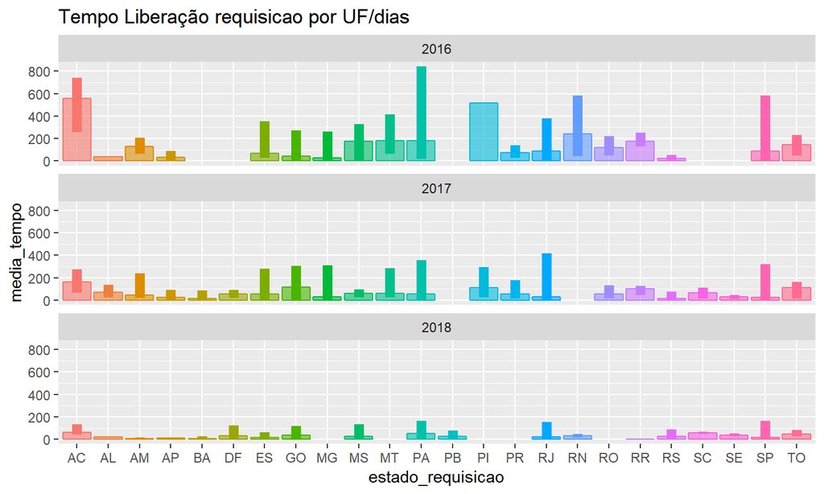

## Gráfico 2: Metodologias solicitadas na rede SUS.

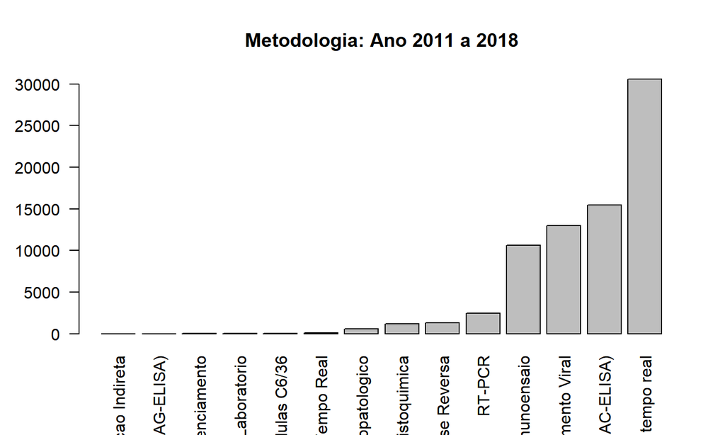

## Gráfico3: Tempo libera??o requisicao da metodologia de PCR, UF/dias.

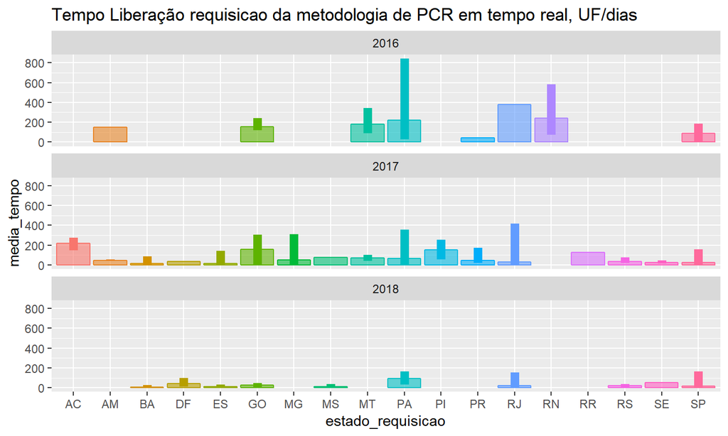

## Gráfico4: Tempo liberação requisicao da metodologia MAC-Elisa, UF/dias.

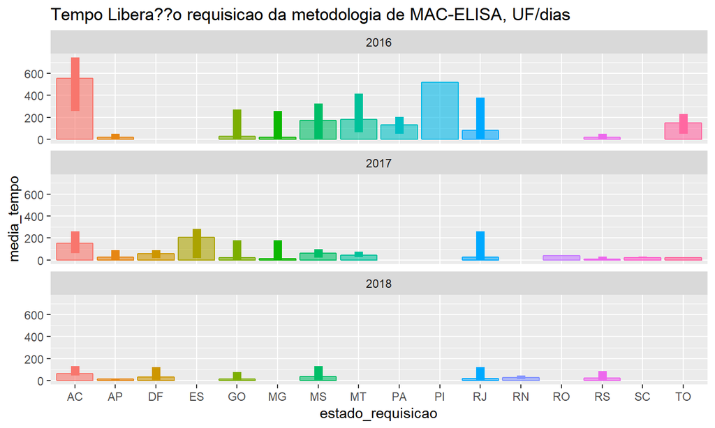

## Gráfico5:Tempo liberção requisicao metodologia Isolamento Viral, UF/dias.

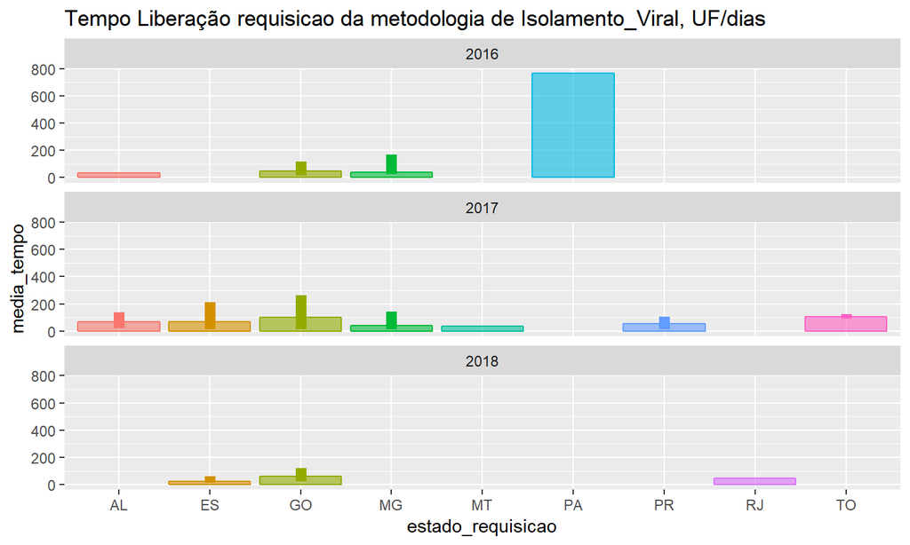

## **CONCLUS?ES**

##### Os resultados apresentados refor?am a import?ncia da qualidade das amostras (fases de coleta, cadastro, transporte, processamento e libera?ao de laudo) que refletem o tempo total de libera?ao da requisi??o e qualidade das informa??es cadastradas no sistema GAL para acompanhamento quantitativo dos exames liberados como potencial ferramenta de alertas epidemiol?gicos, embassamento de priorização da vigilância de doen?as transmissíveis e açoes necessárias para vigilância em saúde do país.